# July 2018 Failed Bank Analysis Comparison

[figure not shown]

In this example, I will demonstrate some quick usage of the R Markdown language to analyze the [FDIC Failed Bank List](https://catalog.data.gov/dataset/fdic-failed-bank-list). This analysis will only scratch the surface of R, but it does take some time to build..

# Intro

First, let’s take a quick look at the data:

```r
banklist <- read.csv("banklist.csv", header = TRUE)
banklist_df <- data.frame(banklist)
head(banklist_df, 50)
```

|  | Bank.Name | City | ST | CERT | Acquiring.Institution | Closing.Date | Updated.Date |
| --- | --- | --- | --- | --- | --- | --- | --- |
| 1 | Washington Federal Bank for Savings | Chicago | IL | 30570 | Royal Savings Bank | 15-Dec-17 | 21-Feb-18 |
| 2 | The Farmers and Merchants State Bank of Argonia | Argonia | KS | 17719 | Conway Bank | 13-Oct-17 | 21-Feb-18 |
| 3 | Fayette County Bank | Saint Elmo | IL | 1802 | United Fidelity Bank, fsb | 26-May-17 | 26-Jul-17 |
| 4 | Guaranty Bank, (d/b/a BestBank in Georgia & Michigan) | Milwaukee | WI | 30003 | First-Citizens Bank & Trust Company | 5-May-17 | 22-Mar-18 |
| 5 | First NBC Bank | New Orleans | LA | 58302 | Whitney Bank | 28-Apr-17 | 5-Dec-17 |
| 6 | Proficio Bank | Cottonwood Heights | UT | 35495 | Cache Valley Bank | 3-Mar-17 | 7-Mar-18 |
| 7 | Seaway Bank and Trust Company | Chicago | IL | 19328 | State Bank of Texas | 27-Jan-17 | 18-May-17 |
| 8 | Harvest Community Bank | Pennsville | NJ | 34951 | First-Citizens Bank & Trust Company | 13-Jan-17 | 18-May-17 |
| 9 | Allied Bank | Mulberry | AR | 91 | Today's Bank | 23-Sep-16 | 25-Sep-17 |
| 10 | The Woodbury Banking Company | Woodbury | GA | 11297 | United Bank | 19-Aug-16 | 1-Jun-17 |

[output cut: 40 more lines]

```r
count(banklist_df)
```

| n |
| --- |
| 555 |

# Relevancy

```r
# We can see the last time the data was updated
banklist_df$Updated.Date <- as.Date(banklist_df$Updated.Date, format = "%d-%b-%y")
## Max Data Update Date
max(sort(banklist_df$Updated.Date, decreasing = TRUE))
```

```
## [1] "2018-07-16"
```

```r
# And do the same for the last closing date
banklist_df$Closing.Date <- as.Date(banklist_df$Closing.Date, format = "%d-%b-%y")
## Last Failed Bank Close Date
max(sort(banklist_df$Closing.Date, decreasing = TRUE))
```

```
## [1] "2017-12-15"
```

# Analysis

So the data has been maintained pretty recently and the last bank closing listed was December of 2017. Not too terrible. Lastly, I’ll show a quick plot of the number of failed banks by state:

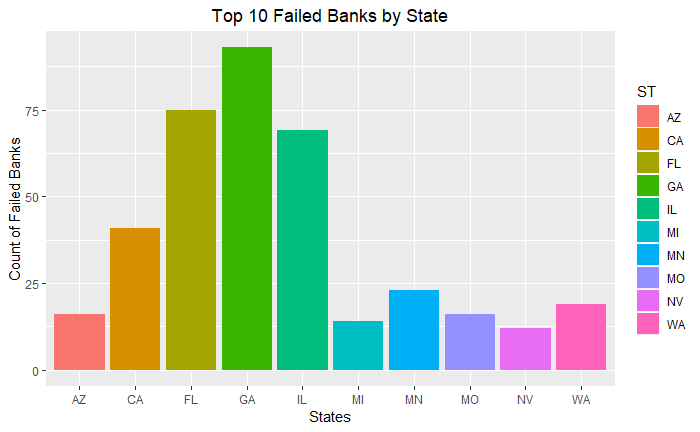

All of this code was written rather hastily in under an hour. Again, I am only scratching the surface of what is possible, but it does take a bit of understanding in R to make this. Someone who uses R frequently could probably mock this up in under 10 minutes, but I’ll admit it took me a good 20 as I have to remember certain functions and their arguments.